# Compare IFN type I vs type II

Kaspar Bresser

11/10/2021

In the bulk and scRNAseq analysis of QPCTL WT and KO mice we detected a enhanced IFN response signature in tumors in a completely KO setting. One of the Referee’s asked if this signature was the result of type I or type II signalling. To figure out whether we can demonstrate this I took 2 approaches, (1) Using the [CytoSig](https://cytosig.ccr.cancer.gov/) database and (2) using the [Interferome](http://www.interferome.org/interferome/home.jspx) database.

```r
library(here)
library(metacell)
library(rstatix)
library(GGally)
library(biomaRt)
library(tidyverse)
```

# CytoSig analysis

## Import and tidy

Import the cytosig dataset. Each column represents a cytokine treatment experiment on a cell model under certain conditions. Each row represents a target gene. Each value is a log2 fold change between treatment and control conditions.

```r
cytosig.data <- read_tsv(here("Data", "Cytosig", "diff.merge"))

cytosig.data
```

```
## # A tibble: 19,918 x 2,057
##    Gene   `TGFB1@Condition:… `TGFB1@Condition… `IFNA&Duration:… `IFNA&Duration:…
##    <chr>               <dbl>             <dbl>            <dbl>            <dbl>
##  1 A1BG             -0.0995            0.114             0.0238       -0.0261
##  2 A1BG-…           -0.120             0.0128           -0.0326       -0.0000583
##  3 A1CF              0.00718           0.00718           0.117        -0.110
##  4 A2M               1.05             -0.242             0.0392       -0.00126
##  5 A4GALT            0.391            -0.632            -0.0101        0.182
##  6 A4GNT             0                -0.0244            0.128        -0.0402
##  7 AAAS             -0.808            -0.132            -0.0533        0.0782
##  8 AACS             -0.488            -0.0374           -0.0364        0.0176
##  9 AADAC             0.191             0.0488            0.100        -0.0996
## 10 AADAT             0.0553            0.330             0.0463        0.0731
## # … with 19,908 more rows, and 2,052 more variables:
## #   IFNA&Duration:1h@Condition:Huh7@GSE48400.MicroArray.GPL10558 <dbl>,
## #   IFNA&Duration:24h@Condition:Huh7@GSE48400.MicroArray.GPL10558 <dbl>,
## #   IFNA&Duration:2h@Condition:Huh7@GSE48400.MicroArray.GPL10558 <dbl>,
## #   IFNA&Duration:4h@Condition:Huh7@GSE48400.MicroArray.GPL10558 <dbl>,
## #   IFNA&Duration:6h@Condition:Huh7@GSE48400.MicroArray.GPL10558 <dbl>,
## #   IFNB&Duration:0.5h@Condition:Huh7@GSE48400.MicroArray.GPL10558 <dbl>,
## #   IFNB&Duration:12h@Condition:Huh7@GSE48400.MicroArray.GPL10558 <dbl>,
## #   IFNB&Duration:1h@Condition:Huh7@GSE48400.MicroArray.GPL10558 <dbl>,
## #   IFNB&Duration:24h@Condition:Huh7@GSE48400.MicroArray.GPL10558 <dbl>,
## #   IFNB&Duration:2h@Condition:Huh7@GSE48400.MicroArray.GPL10558 <dbl>,
## #   IFNB&Duration:4h@Condition:Huh7@GSE48400.MicroArray.GPL10558 <dbl>,
## #   IFNB&Duration:6h@Condition:Huh7@GSE48400.MicroArray.GPL10558 <dbl>,
## #   IFNL&Duration:0.5h@Condition:Huh7@GSE48400.MicroArray.GPL10558 <dbl>,
## #   IFNL&Duration:12h@Condition:Huh7@GSE48400.MicroArray.GPL10558 <dbl>,
## #   IFNL&Duration:1h@Condition:Huh7@GSE48400.MicroArray.GPL10558 <dbl>,
## #   IFNL&Duration:24h@Condition:Huh7@GSE48400.MicroArray.GPL10558 <dbl>,
## #   IFNL&Duration:2h@Condition:Huh7@GSE48400.MicroArray.GPL10558 <dbl>,
## #   IFNL&Duration:4h@Condition:Huh7@GSE48400.MicroArray.GPL10558 <dbl>,
## #   IFNL&Duration:6h@Condition:Huh7@GSE48400.MicroArray.GPL10558 <dbl>,
## #   TGFB1&Dose:15ng/mL_Duration:48h@Condition:Epidermal Keratinocyte@GSE24965.MicroArray.GPL6947 <dbl>,
## #   TNFA&Dose:40 ng/ml@Condition:MDA-MB-231_with Apigenin@GSE120550.MicroArray.GPL17692 <dbl>,
## #   TNFA&Dose:40 ng/ml@Condition:MDA-MB-231_without Apigenin@GSE120550.MicroArray.GPL17692 <dbl>,
## #   TNFA&Dose:100 ng/ml@Condition:HT-29 colorectal adenocarcinoma cell line&Duration:16h@GSE69639.MicroArray.GPL96 <dbl>,
## #   TNFA&Dose:5 ng/ml@Condition:HT-29 colorectal adenocarcinoma cell line&Duration:16h@GSE69639.MicroArray.GPL96 <dbl>,
## #   TNFA&Dose:100 ng/ml@Condition:HT-29 colorectal adenocarcinoma cell line&Duration:4h@GSE69639.MicroArray.GPL96 <dbl>,
## #   TNFA&Dose:5 ng/ml@Condition:HT-29 colorectal adenocarcinoma cell line&Duration:4h@GSE69639.MicroArray.GPL96 <dbl>,
```

[output cut: 60 more lines]

```
## #   IFNG@Condition:Microglia&Duration:1h@GSE1432.MicroArray.GPL96 <dbl>,
## #   IFNG@Condition:Microglia&Duration:24h@GSE1432.MicroArray.GPL96 <dbl>,
## #   IFNG@Condition:Microglia&Duration:6h@GSE1432.MicroArray.GPL96 <dbl>,
## #   TNFA@Condition:HepG2&Duration:72h@GSE122660.MicroArray.GPL13158 <dbl>,
## #   TNFA@Condition:HuH7&Duration:72h@GSE122660.MicroArray.GPL13158 <dbl>,
## #   TNFA@Condition:PHH&Duration:72h@GSE122660.MicroArray.GPL13158 <dbl>,
## #   IL1B&Duration:4h@Condition:Chondrocyte@GSE74220.RNASeq.SRP065219_GRCh38 <dbl>,
## #   IL1B&Dose:5ng/ml_Duration:3h@Condition:HUVEC DHA pretreated@GSE57825.MicroArray.GPL4133 <dbl>,
## #   IFNG@Condition:Fibrosarcoma.HT1080@GSE128392.RNASeq.SRP188564_GRCh38 <dbl>,
## #   TNFA@Condition:Endothelial@GSE6257.MicroArray.HG-U133_Plus_2 <dbl>,
## #   IFNA@Condition:B-cell@GSE117637.RNASeq.SRP155182_GRCh38 <dbl>,
## #   IFNA@Condition:Fibroblast@GSE117637.RNASeq.SRP155182_GRCh38 <dbl>,
## #   TGFB1@GSE72696.RNASeq.SRP063675_GRCh38 <dbl>,
## #   TGFB1@Condition:primary human lung fibroblasts_AZD8055 treatment&Duration:24h@GSE102674.RNASeq.SRP115472_GRCh38 <dbl>,
## #   …
```

Select only to columns that relate to our cytokines of interest, switch to long form, and extract cytokine identity into a separate column.

```r
cytosig.data %>%
  select(Gene, contains("IFNA"), contains("IFNB"), contains("IFNG")) %>%
  pivot_longer(cols = -Gene, names_to = "assay", values_to = "FC") %>%
  mutate(cytokine = str_extract(assay, "^IFN\\w{1}")) -> cytosig.IFN

cytosig.IFN
```

```
## # A tibble: 8,126,544 x 4
##    Gene  assay                                                       FC cytokine
##    <chr> <chr>                                                    <dbl> <chr>
##  1 A1BG  IFNA&Duration:0.5h@Condition:Huh7@GSE48400.MicroArra…  0.0238  IFNA
##  2 A1BG  IFNA&Duration:12h@Condition:Huh7@GSE48400.MicroArray… -0.0261  IFNA
##  3 A1BG  IFNA&Duration:1h@Condition:Huh7@GSE48400.MicroArray.…  0.0232  IFNA
##  4 A1BG  IFNA&Duration:24h@Condition:Huh7@GSE48400.MicroArray… -0.0114  IFNA
##  5 A1BG  IFNA&Duration:2h@Condition:Huh7@GSE48400.MicroArray.… -0.0377  IFNA
##  6 A1BG  IFNA&Duration:4h@Condition:Huh7@GSE48400.MicroArray.… -0.0328  IFNA
##  7 A1BG  IFNA&Duration:6h@Condition:Huh7@GSE48400.MicroArray.… -0.0535  IFNA
##  8 A1BG  IFNA@Condition:SLE keratinocytes@GSE124939.RNASeq.SR… -0.00718 IFNA
##  9 A1BG  IFNA@Condition:normal keratinocytes@GSE124939.RNASeq…  0.00718 IFNA
## 10 A1BG  IFNA&Duration:12h@Condition:BE(2)-C@GSE16450.MicroAr…  0.183   IFNA
## # … with 8,126,534 more rows
```

## Calculate scores

Remove any `NA`’s that were formed, as some genes were probably not detected in each assay. Then calculate the median log2 FC. Probably not the ideal metric, but should give us a rough idea of the association between gene-induction and IFN subtype.

```r
cytosig.IFN %>%
  na.omit() %>%
  group_by(Gene, cytokine) %>%
  summarise(score = median(FC, na.rm = T)) %>%
  pivot_wider(names_from = cytokine, values_from = score) -> cytosig.IFN

cytosig.IFN
```

```
## # A tibble: 18,292 x 4
## # Groups:   Gene [18,292]
##    Gene         IFNA     IFNB     IFNG
##    <chr>       <dbl>    <dbl>    <dbl>
##  1 A1BG     -0.0157  -0.00898 -0.0135
##  2 A1BG-AS1 -0.0436  -0.0275   0
##  3 A1CF     -0.00677 -0.0130   0.00104
##  4 A2M      -0.00775  0        0.0640
##  5 A2ML1     0.00521  0        0
##  6 A4GALT   -0.0210  -0.00614 -0.0310
##  7 A4GNT     0       -0.00796 -0.0148
##  8 AAAS     -0.0315  -0.0709  -0.0566
##  9 AACS     -0.0165  -0.0272  -0.0676
## 10 AACSP1    0        0        0
## # … with 18,282 more rows
```

Lets have a look at the correlations between these signatures.

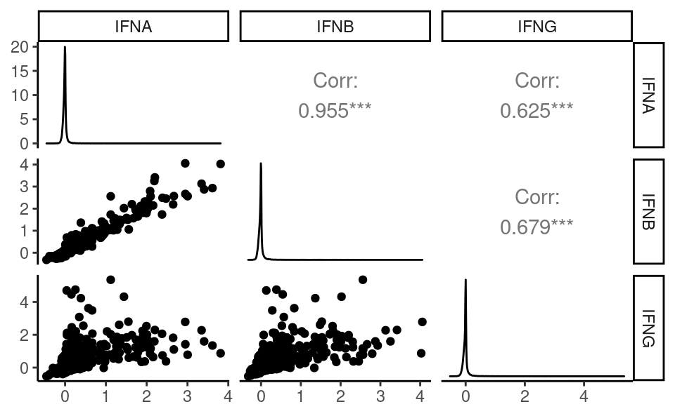

```r
ggpairs(cytosig.IFN, columns = c("IFNA", "IFNB", "IFNG"))
```

## Map mouse to human gene symbols

The CytoSig database was constructed based on human data, our data is a mouse data-set, can use `biomaRt` to map these to each other, af far as possible.

Retrieve the mouse gene symbols.

```r
human <- useMart("ensembl", dataset = "hsapiens_gene_ensembl")
mouse <- useMart("ensembl", dataset = "mmusculus_gene_ensembl")

conversion <- getLDS(attributes = c("hgnc_symbol"),
                     filters = "hgnc_symbol",
                     values = cytosig.IFN$Gene ,
                     mart = human,
                     attributesL = c("mgi_symbol"),
                     martL = mouse,
                     uniqueRows=T)

tail(conversion, 10)
```

```
##       HGNC.symbol MGI.symbol
## 18093    MAPKAPK5    Gm42878
## 18094    MAPKAPK5   Mapkapk5
## 18095         SHB        Shb
## 18096       DCAF7      Dcaf7
## 18097       RNF25      Rnf25
## 18098      FRMPD1     Frmpd1
## 18099     MSANTD4    Msantd4
## 18100        DLX4       Dlx4
## 18101      GPR179     Gpr179
## 18102      ZNF324     Zfp324
```

Now import the tumor data.

```r
scdb_init(here("Data", "Metacell_files"), force_reinit=T)
mc.tumor <- scdb_mc("QPCTL_Tum_MC2")

lfp <- as_tibble(log2(mc.tumor@mc_fp), rownames = "Gene" )
```

MetaCell 12 was the cell cluster that exhibited an enhanced IFN signature.

Join with conversion table and with cytosig data.

```r
lfp %>%
  rename(MC12 = `12`) %>%
  dplyr::select(Gene, MC12) %>%
  inner_join(conversion, c("Gene" = "MGI.symbol")) %>%
  inner_join(cytosig.IFN, c("HGNC.symbol" = "Gene")) -> combined.data
```

## Compare signatures

Check the correlations.

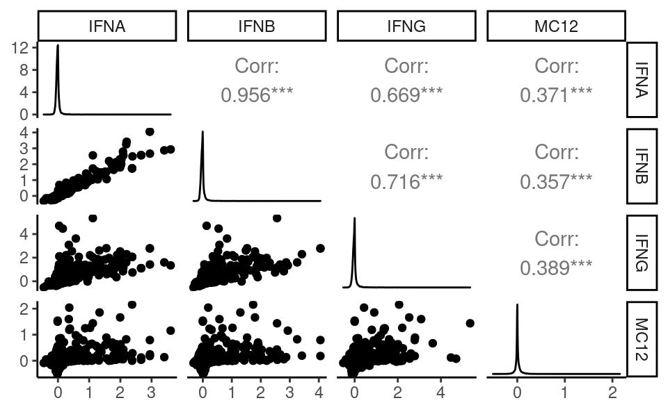

```r
ggpairs(combined.data, columns = c("IFNA", "IFNB", "IFNG", "MC12"), )
```

Gene-enrichment in MC12 does not seem to have a stronger correlation with any of the signatures.

Another way of looking at the data could be to zoom in on the top 100 enriched genes in MC12 and plot the score distribution for each of the signatures.

```r
combined.data %>%
  slice_max(order_by = MC12, n = 100) %>%
  pivot_longer(cols = contains("IFN"), names_to = "type", values_to = "score") %>%
  t_test(score~type)
```

```
## # A tibble: 3 x 10
##   .y.   group1 group2    n1    n2 statistic    df     p p.adj p.adj.signif
## * <chr> <chr>  <chr>  <int> <int>     <dbl> <dbl> <dbl> <dbl> <chr>
## 1 score IFNA   IFNB     100   100    -0.497  197. 0.62  0.64  ns
## 2 score IFNA   IFNG     100   100    -1.51   193. 0.134 0.402 ns
## 3 score IFNB   IFNG     100   100    -0.997  196. 0.32  0.64  ns
```

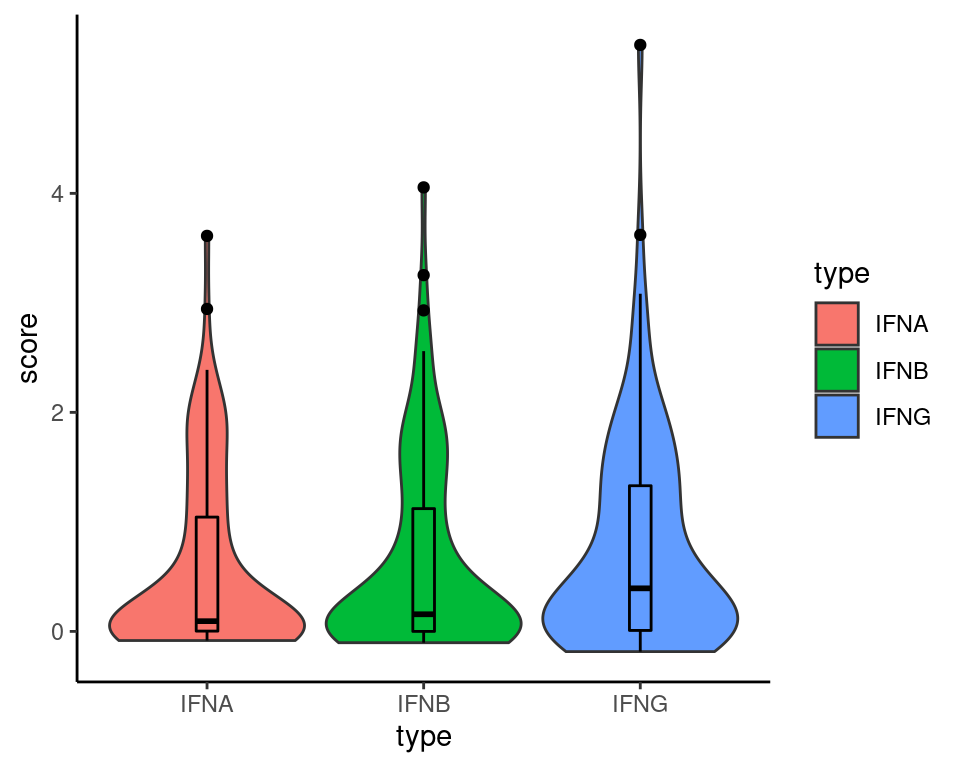

```r
combined.data %>%
  slice_max(order_by = MC12, n = 100) %>%
  pivot_longer(cols = contains("IFN"), names_to = "type", values_to = "score") %>%
  ggplot(aes(type, score, fill = type))+
  geom_violin(scale = "width")+
  geom_boxplot(color = "black", width = .1, fill = NA)
```

# Interferome analysis

The interferome database allows one to search a list of genes, returning information on a curated set of studies that examined transcriptional signatures in response to type I, II or III IFNs. I’ll extract the top 100 genes in MC12 and examine whether these genes have been found to be induced by type I or II IFNs.

```r
combined.data %>%
  slice_max(order_by = MC12, n = 100) %>%
  pull(Gene) %>%
  write_lines(here("Output", "MC12_genes.txt"))
```

I used the created file as input for [Interferome](http://www.interferome.org/interferome/home.jspx), the first lines contain information on the search metrics, actual data starts on line 20.

```r
search.info <- read_lines(here("Data", " Interferome_top100_results.txt"), n_max = 19)
cat(paste0(search.info, collapse = "\n"))
```

```
## Search Conditions
##
## Interferome Type Any
## Interferome SubType  Any
## Treatment Concentration  Any
## Treatment Time   Any
## Vivo/Vitro   Any
## Species  Mus musculus
## System   Any
## Organ    Any
## Cell Any
## Cell Line    Any
## Normal/Abnormal  Any
## Fold Change Up   2.0
## Fold Change Down 2.0
## Gene Symbol List Ifitm3;B2m;Bst2;Stat1;Gbp2;Irgm1;Igtp;Cxcl10;Psmb9;Psmb8;Psmb10;Psme1;Isg15;Psme2;Tap1;Rnf213;Zbp1;Gbp4;Rsad2;Ifit3;Lgals3bp;Tapbp;Xaf1;Irf1;Ifi203;Ifi35;Herc6;Parp12;Nmi;Parp14;Snx10;Rtp4;Ifit1;Irgm2;Lgals9;Lgals9;Lap3;Fabp5;Eif2ak2;Cd74;Psma4;Samd9l;Tap2;Ppa1;Tmem140;Ak2;Ddx58;…
##
## Found a total of 4646 Data
```

```r
IRF.results <- read_tsv(here("Data", " Interferome_top100_results.txt"), skip = 19 )
IRF.results
```

```
## # A tibble: 4,646 x 9
##    `Dataset ID` `Fold Change` `Inteferome Type` `Treatment Time` `Gene Name`
##           <dbl>         <dbl> <chr>                        <dbl> <chr>
##  1          151          2.12 II                               6 Apol9a
##  2          282          3.97 I                               10 Apol9a
##  3          283          3.27 I                               10 Apol9a
##  4          286          3.32 II                               4 Apol9a
##  5          287          3.19 II                               4 Apol9a
##  6          288          2.20 I                                6 Apol9a
##  7          289          4.09 I                                6 Apol9a
##  8           51          2.50 II                               6 Apol9a
##  9           71          3.42 I                               24 Apol9a
## 10           72         15.3  I                                3 Apol9a
## # … with 4,636 more rows, and 4 more variables: Description <chr>,
## #   GenBank Accession <chr>, Ensembl ID <chr>, Probe ID <chr>
```

Transform data a bit to figure out whether genes were found in studies using either type I, type II or both.

```r
IRF.results %>%
  count(`Gene Name`, `Inteferome Type`) %>%
  pivot_wider(names_from = "Inteferome Type", values_from = n, values_fill =  0) %>%
  mutate(IFN.type = case_when(I == 0 ~ "type II",
                              II == 0 ~ "type I",
                              TRUE ~ "both")) -> IRF.genes

IRF.genes
```

```
## # A tibble: 83 x 4
##    `Gene Name`     I    II IFN.type
##    <chr>       <int> <int> <chr>
##  1 Apol9a         19     4 both
##  2 B2m            42    11 both
##  3 Bst2           49    11 both
##  4 C2             18     3 both
##  5 Cacybp          4     0 type I
##  6 Cadm1           0     3 type II
##  7 Cd74            5    19 both
##  8 Cmpk2          72    18 both
##  9 Cxcl10         58    31 both
## 10 Ddx58         117    14 both
## # … with 73 more rows
```

Plot the counts

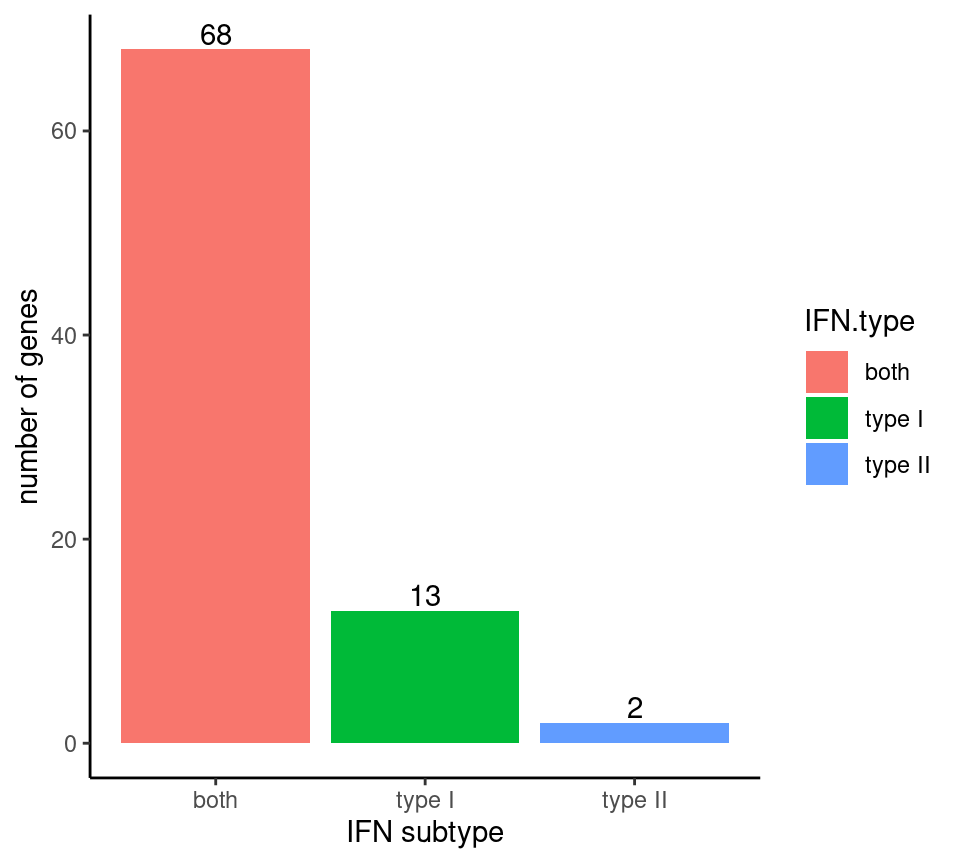

```r
ggplot(IRF.genes, aes(IFN.type, fill = IFN.type))+
  geom_bar(stat="count")+
  geom_text(stat="count", aes(label=..count..), vjust=-0.2)+
  labs(x = "IFN subtype", y = "number of genes")
```